# Local Item Dependency: *Continued*

Psychologische Institut für psychologische Methodenlehre, Evaluation und Statistik

~

Carolina Fellinghauer

carolina.fellinghauer@uzh.ch

7 7 2020

```r
library(eRm)

urlfunction <- "https://raw.githubusercontent.com/CarolinaFellinghauer/UNIZH_HS2020_Rasch/master/RFunctions/LIDGraph.R?token=AB5GB42GG6I6YI2MF3KDINC7K5JG6"

source(urlfunction)
```

# Local Item Dependency

Items are said locally dependent when the correlation of the $Q_3$ statistic, i.e. the standardized Rasch residuals is above a cut-off. The selected cut-off size is matter of discussion but recent simulation studies of Christensen, Makransky, and Horton (2017) showed that they should not exceed more than 0.2 above the average residual correlation
$$Q^{\star}_3=Q_{3,max}-\bar{Q_3}>0.2$$
This lesson builds on the results found in the preceding exercise using the MDS capacity data.

Let’s start by loading the data:

```r
# get the MDS dataset from GitHub

urlfile <- "https://raw.githubusercontent.com/CarolinaFellinghauer/UNIZH_HS2020_Rasch/master/Data/WHO_MDS_course.csv?token=AB5GB46B55WMO5AU74G4CKK7K5JSG"

MDS.data <- read.csv(url(urlfile), sep = ";")

# Select only the MDS items, these are all columns except the first four.  It
# starts with vision.

mds.items <- colnames(MDS.data)[-(1:4)]

# data only with the items
data.mds <- MDS.data[, mds.items]

# make them start at zero
data.mds <- data.mds - 1
```

# Adjustment

In the last exercise, the capacity items of the MDS survey showed strong LID for many items. One approach to solve local item dependencies is to create ‘testlets’, also sometimes called ‘super-items’.

Testlets simply consist of a summation of the LID items. Typically, one would not solve all the LID at once but, stepwise starting with the highest correlation(s).

The results of the previous exercises showed two pair of items with LID above 0.7, these were:

- *Depressivity* & *Anxiety* ($r = 0.7567$)
- *Going out* & *Shopping* ($r = 0.7011$)

Creating a testlet means, that the separate items will not be kept, but the sum of the dependent items used instead.

```r
# what was the name of the variables...
colnames(data.mds)
```

```
 [1] "Vision"        "Hearing"       "Walking"       "Memory"
 [5] "Dressing"      "Communication" "Feeding"       "Toileting"
 [9] "Bed"           "GoingOut"      "Shopping"      "HandUse"
[13] "Sleeping"      "Breathing"     "Household"     "Caring"
[17] "Participating" "Depressivity"  "Anxiety"       "GettingAlong"
[21] "Managing"      "Pain"
```

```r
# testlet for Depressivity & Anxiety
data.mds[, "Testlet1"] <- rowSums(data.mds[, c("Depressivity", "Anxiety")], na.rm = TRUE)

# this is same as

# data.mds[, 'Testlet1'] = data.mds[,'Depressivity'] + data.mds[, 'Anxiety']

# or

# data.mds[, 'Testlet1'] = apply(data.mds[,c('Depressivity', 'Anxiety')], 1, sum,
# na.rm = TRUE)


# second testlet GoingOut and Shopping
data.mds[, "Testlet2"] <- rowSums(data.mds[, c("GoingOut", "Shopping")], na.rm = TRUE)

# having a look at the frequency distribution in the testlet

table(data.mds[, "Testlet1"])
```

```
  0   1   2   3   4   5   6   7   8
105  43 123  24 171  34 205  25 270
```

```r
table(data.mds[, "Testlet2"])
```

```
  0   1   2   3   4   5   6   7   8
255  25  59  19  71  36  96  32 407
```

```r
# Removing the items from the dataset before running the PCM

# Probably fancier ways to do it - thinking dplyr or else...

data.mds <- data.mds[, -which(colnames(data.mds) %in% c("Depressivity", "Anxiety",
    "GoingOut", "Shopping") == TRUE)]

# check if testlet creation and removal of the LID items worked table by column

apply(data.mds, 2, table, useNA = "always")
```

```
$Vision

   0    1    2    3    4 <NA>
 149   97  209  271  274    0

$Hearing

   0    1    2    3    4 <NA>
 513  122  135  108  122    0

$Walking

   0    1    2    3    4 <NA>
 195   82  151  206  366    0

$Memory

   0    1    2    3    4 <NA>
 266  154  215  149  216    0

$Dressing

   0    1    2    3    4 <NA>
 391  103  117  142  247    0

$Communication

   0    1    2    3    4 <NA>
 563  100   98   85  154    0

$Feeding

   0    1    2    3    4 <NA>
 535   92   99   85  189    0

$Toileting

   0    1    2    3    4 <NA>
 483   58  103   90  266    0

```

[output cut: 44 more lines]

```

$Pain

   0    1    2    3    4 <NA>
  90   73  207  244  386    0

$Testlet1

   0    1    2    3    4    5    6    7    8 <NA>
 105   43  123   24  171   34  205   25  270    0

$Testlet2

   0    1    2    3    4    5    6    7    8 <NA>
 255   25   59   19   71   36   96   32  407    0
```

```r
dim(data.mds)
```

```
[1] 1000   20
```

Now that the testlets are created, the PCM analysis and diagnostics are run as usual.

```r
PCM.mds.testlet1 <- PCM(data.mds)
```

A visual analysis of the impact of the testlets on the LID can be done with LIDgraph(), first checking if LID of the size observed previously ($r > 0.7$) are still found.

```r
LIDgraph(PCM.mds.testlet1, cut = 0.7, vertex.color = "pink", vertex.size = 25, vertex.label.dist = 0,
    cex = 0.45)
```

```
No associations found above cut-off = 0.7!
```

The output tells us that they are no more associations above the cut-off of $r = 0.7$.

What about the cut-off recommended by Christensen, Makransky, and Horton (2017).

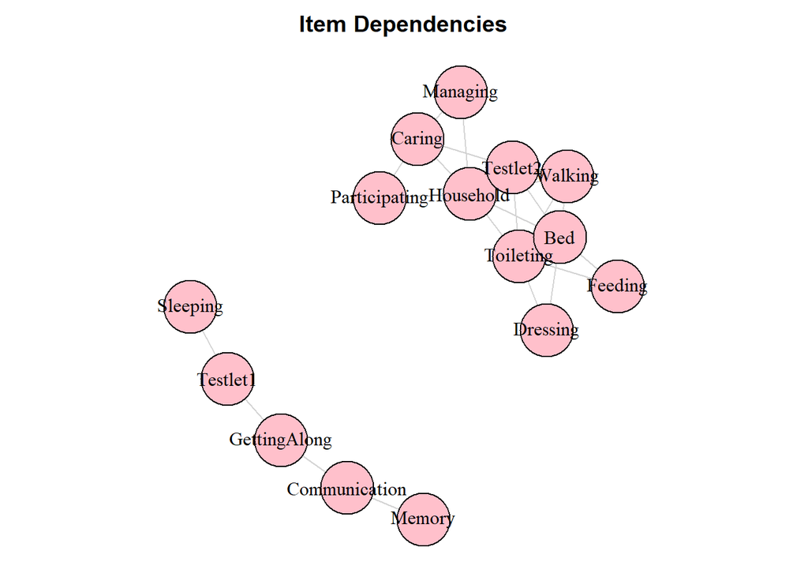

```
$LID
              Vision Hearing Walking Memory Dressing Communication Feeding
Vision        ""     ""      ""      ""     ""       ""            ""
Hearing       ""     ""      ""      ""     ""       ""            ""
Walking       ""     ""      ""      ""     ""       ""            ""
Memory        ""     ""      ""      ""     ""       "0.2806"      ""
Dressing      ""     ""      ""      ""     ""       ""            ""
Communication ""     ""      ""      ""     ""       ""            ""
Feeding       ""     ""      ""      ""     ""       ""            ""
Toileting     ""     ""      ""      ""     ""       ""            ""
Bed           ""     ""      ""      ""     ""       ""            ""
HandUse       ""     ""      ""      ""     ""       ""            ""
Sleeping      ""     ""      ""      ""     ""       ""            ""
Breathing     ""     ""      ""      ""     ""       ""            ""
Household     ""     ""      ""      ""     ""       ""            ""
Caring        ""     ""      ""      ""     ""       ""            ""
Participating ""     ""      ""      ""     ""       ""            ""
GettingAlong  ""     ""      ""      ""     ""       ""            ""
Managing      ""     ""      ""      ""     ""       ""            ""
Pain          ""     ""      ""      ""     ""       ""            ""
Testlet1      ""     ""      ""      ""     ""       ""            ""
Testlet2      ""     ""      ""      ""     ""       ""            ""
              Toileting Bed      HandUse Sleeping Breathing Household Caring
Vision        ""        ""       ""      ""       ""        ""        ""
Hearing       ""        ""       ""      ""       ""        ""        ""
Walking       "0.1732"  "0.2325" ""      ""       ""        "0.1796"  ""
Memory        ""        ""       ""      ""       ""        ""        ""
Dressing      "0.3522"  "0.3333" ""      ""       ""        ""        ""
Communication ""        ""       ""      ""       ""        ""        ""
Feeding       "0.4432"  "0.2347" ""      ""       ""        ""        ""
Toileting     ""        "0.4503" ""      ""       ""        "0.1952"  ""
Bed           ""        ""       ""      ""       ""        "0.2067"  ""
HandUse       ""        ""       ""      ""       ""        ""        ""
Sleeping      ""        ""       ""      ""       ""        ""        ""
Breathing     ""        ""       ""      ""       ""        ""        ""
Household     ""        ""       ""      ""       ""        ""        "0.2674"
Caring        ""        ""       ""      ""       ""        ""        ""
Participating ""        ""       ""      ""       ""        ""        ""
GettingAlong  ""        ""       ""      ""       ""        ""        ""
Managing      ""        ""       ""      ""       ""        ""        ""
```

[output cut: 12 more lines]

```
Bed           ""            ""           ""       ""   ""       "0.2284"
HandUse       ""            ""           ""       ""   ""       ""
Sleeping      ""            ""           ""       ""   "0.223"  ""
Breathing     ""            ""           ""       ""   ""       ""
Household     "0.2203"      ""           "0.2343" ""   ""       "0.2404"
Caring        "0.2466"      ""           "0.1867" ""   ""       "0.1937"
Participating ""            ""           ""       ""   ""       ""
GettingAlong  ""            ""           ""       ""   "0.2016" ""
Managing      ""            ""           ""       ""   ""       ""
Pain          ""            ""           ""       ""   ""       ""
Testlet1      ""            ""           ""       ""   ""       ""
Testlet2      ""            ""           ""       ""   ""       ""

$cut.off
[1] 0.1602237
```

```r
LIDgraph(PCM.mds.testlet1, cut = "Q3star", vertex.color = "pink", vertex.size = 25,
    vertex.label.dist = 0, cex = 0.45, print.out = TRUE)
```

```r
# what was the name of the variables...
colnames(data.mds)
```

```
 [1] "Vision"        "Hearing"       "Walking"       "Memory"
 [5] "Dressing"      "Communication" "Feeding"       "Toileting"
 [9] "Bed"           "HandUse"       "Sleeping"      "Breathing"
[13] "Household"     "Caring"        "Participating" "GettingAlong"
[17] "Managing"      "Pain"          "Testlet1"      "Testlet2"
```

```r
# testlet for Toileting & Bed
data.mds[, "Testlet3"] <- rowSums(data.mds[, c("Toileting", "Bed")], na.rm = TRUE)

# second testlet Feeding & Toileting
data.mds[, "Testlet4"] <- rowSums(data.mds[, c("Feeding", "Toileting")], na.rm = TRUE)

# having a look at the frequency distribution in the testlet

table(data.mds[, "Testlet3"])
```

```
  0   1   2   3   4   5   6   7   8
344  67  65  54  69  44  78  32 247
```

```r
table(data.mds[, "Testlet4"])
```

```
  0   1   2   3   4   5   6   7   8
456  33  69  34  76  58  64  32 178
```

```r
# Removing the 3 items from the dataset before running the PCM

data.mds <- data.mds[, -which(colnames(data.mds) %in% c("Bed", "Feeding", "Toileting") ==
    TRUE)]

# check if testlet creation and removal of the LID items worked table by column

apply(data.mds, 2, table, useNA = "always")
```

```
$Vision

   0    1    2    3    4 <NA>
 149   97  209  271  274    0

$Hearing

   0    1    2    3    4 <NA>
 513  122  135  108  122    0

$Walking

   0    1    2    3    4 <NA>
 195   82  151  206  366    0

$Memory

   0    1    2    3    4 <NA>
 266  154  215  149  216    0

$Dressing

   0    1    2    3    4 <NA>
 391  103  117  142  247    0

$Communication

   0    1    2    3    4 <NA>
 563  100   98   85  154    0

$HandUse

   0    1    2    3    4 <NA>
 372   86  134  156  252    0

$Sleeping

   0    1    2    3    4 <NA>
 223   83  192  239  263    0

```

[output cut: 39 more lines]

```

$Testlet2

   0    1    2    3    4    5    6    7    8 <NA>
 255   25   59   19   71   36   96   32  407    0

$Testlet3

   0    1    2    3    4    5    6    7    8 <NA>
 344   67   65   54   69   44   78   32  247    0

$Testlet4

   0    1    2    3    4    5    6    7    8 <NA>
 456   33   69   34   76   58   64   32  178    0
```

```r
dim(data.mds)
```

```
[1] 1000   19
```

Running again the PCM with 2 additional testlets representing the self-care items.

```r
PCM.mds.testlet2 <- PCM(data.mds)
```

See if the association pattern is generally ameliorated.

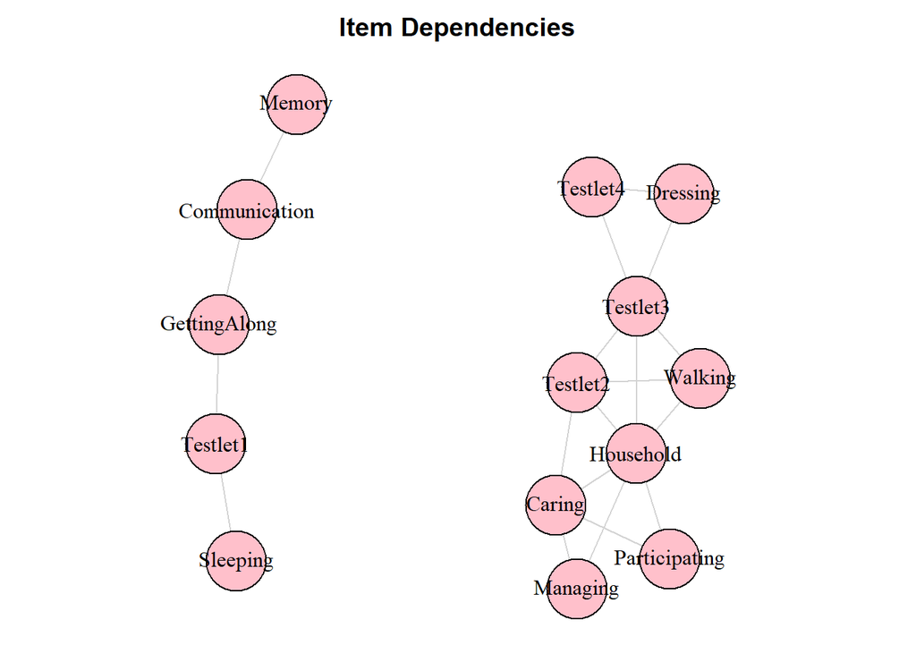

```
$LID
              Vision Hearing Walking Memory Dressing Communication HandUse
Vision        ""     ""      ""      ""     ""       ""            ""
Hearing       ""     ""      ""      ""     ""       ""            ""
Walking       ""     ""      ""      ""     ""       ""            ""
Memory        ""     ""      ""      ""     ""       "0.2879"      ""
Dressing      ""     ""      ""      ""     ""       ""            ""
Communication ""     ""      ""      ""     ""       ""            ""
HandUse       ""     ""      ""      ""     ""       ""            ""
Sleeping      ""     ""      ""      ""     ""       ""            ""
Breathing     ""     ""      ""      ""     ""       ""            ""
Household     ""     ""      ""      ""     ""       ""            ""
Caring        ""     ""      ""      ""     ""       ""            ""
Participating ""     ""      ""      ""     ""       ""            ""
GettingAlong  ""     ""      ""      ""     ""       ""            ""
Managing      ""     ""      ""      ""     ""       ""            ""
Pain          ""     ""      ""      ""     ""       ""            ""
Testlet1      ""     ""      ""      ""     ""       ""            ""
Testlet2      ""     ""      ""      ""     ""       ""            ""
Testlet3      ""     ""      ""      ""     ""       ""            ""
Testlet4      ""     ""      ""      ""     ""       ""            ""
              Sleeping Breathing Household Caring   Participating GettingAlong
Vision        ""       ""        ""        ""       ""            ""
Hearing       ""       ""        ""        ""       ""            ""
Walking       ""       ""        "0.184"   ""       ""            ""
Memory        ""       ""        ""        ""       ""            ""
Dressing      ""       ""        ""        ""       ""            ""
Communication ""       ""        ""        ""       ""            "0.1687"
HandUse       ""       ""        ""        ""       ""            ""
Sleeping      ""       ""        ""        ""       ""            ""
Breathing     ""       ""        ""        ""       ""            ""
Household     ""       ""        ""        "0.2773" "0.2307"      ""
Caring        ""       ""        ""        ""       "0.2562"      ""
Participating ""       ""        ""        ""       ""            ""
GettingAlong  ""       ""        ""        ""       ""            ""
Managing      ""       ""        ""        ""       ""            ""
Pain          ""       ""        ""        ""       ""            ""
Testlet1      ""       ""        ""        ""       ""            ""
Testlet2      ""       ""        ""        ""       ""            ""
Testlet3      ""       ""        ""        ""       ""            ""
```

[output cut: 9 more lines]

```
Sleeping      ""       ""   "0.2294" ""       ""       ""
Breathing     ""       ""   ""       ""       ""       ""
Household     "0.239"  ""   ""       "0.2454" "0.1979" ""
Caring        "0.2023" ""   ""       "0.1915" ""       ""
Participating ""       ""   ""       ""       ""       ""
GettingAlong  ""       ""   "0.2094" ""       ""       ""
Managing      ""       ""   ""       ""       ""       ""
Pain          ""       ""   ""       ""       ""       ""
Testlet1      ""       ""   ""       ""       ""       ""
Testlet2      ""       ""   ""       ""       "0.2172" ""
Testlet3      ""       ""   ""       ""       ""       "0.6267"
Testlet4      ""       ""   ""       ""       ""       ""

$cut.off
[1] 0.1552549
```

```r
LIDgraph(PCM.mds.testlet2, cut = "Q3star", vertex.color = "pink", vertex.size = 25,
    vertex.label.dist = 0, cex = 0.45, print.out = TRUE)
```

We could continue adressing stepwise the LID of the MDS items. When the strongest correlating items are adjusted for, weaker associations may disappear. On the other hand, the MDS-items are interrelated in a way, that a testlet approach to solve all the dependencies is tedious.

Ideally, while solving for the LID, the model fit (PSI), item fit could also be tested for, we leave that for the exercise, with a simpler dataset.

LID is close to another assumption that the Rasch model needs to test, i.e. multidimensionality. It can be expected, that some association clusters are so strong, that the pairwise dependencies it consists of may represent a distinct assessment dimension of a latent construct.

# Exercise

Use the SRG data and create testlets with the LID items found previously. Run a PCM analysis and provide:

- the model’s reliability before and after testlet creation
- the model’s item fit statistic
- the size of LID after creation of testlet(s).

# References

Christensen, Karl Bang, Guido Makransky, and Mike Horton. 2017. “Critical Values for Yen’s Q3: Identification of Local Dependence in the Rasch Model Using Residual Correlations.” *Applied Psychological Measurement* 41 (3): 178–94. https://doi.org/doi:10.1177/0146621616677520.